# Cell deconvolution

Truong Nguyen

2025-06-07

# Loading packages

```r
#BiocManager::install("FlowSorted.Blood.450k")
#BiocManager::install("methylCC")
library(FlowSorted.Blood.450k)
```

```
## locfit 1.5-9.10   2024-06-24
```

```
## Setting options('download.file.method.GEOquery'='auto')
```

```
## Setting options('GEOquery.inmemory.gpl'=FALSE)
```

```r
library(methylCC)
library(minfi)
library(tidyr)
library(dplyr)
```

```r
library(tibble)
library(ggplot2)
library(tidyverse)
library(data.table)
library(compositions)
library(FactoMineR)
library(factoextra)
library(vegan)
library(cluster)
library(umap)
library(pheatmap)
library(RColorBrewer)
library(gghalves)
library(rpart)
library(rpart.plot)
library(devtools)
library(abind)
library(sesame)
library(rtracklayer)
library(dplyr)
library(magrittr)
library(S4Vectors)
library(methylkey)
library(DT)
library(SummarizedExperiment)
library(limma)
library(ggrepel)
library(GenomicRanges)
library(ggpubr)
library(DMRcate)
```

# Loading data

```r
bulk_sample <- read.csv("/Users/macos/Desktop/Job_applications/VIB/Meth_atlas/bulk_samples.csv", stringsAsFactors = FALSE)
dim(bulk_sample)
```

```
## [1] 500  51
```

```r
reference_sample <- read.csv("/Users/macos/Desktop/Job_applications/VIB/Meth_atlas/reference_samples.csv", stringsAsFactors = FALSE)
dim(reference_sample)
```

```
## [1] 333   8
```

# Loading cell deconvolution results

These downstream analyses were performed on the results of cell deconvolution using deconvolve.py (nloyfer/meth_atlas)

```r
fractions_file <- "/Users/macos/Desktop/Job_applications/VIB/Meth_atlas/bulk_samples_deconv_output.csv"
frac <- fread(fractions_file) |> column_to_rownames("V1") |> as.matrix()
residuals_file <- "/Users/macos/Desktop/Job_applications/VIB/Meth_atlas/bulk_samples_residuals.csv"
resid <- fread(residuals_file) |> column_to_rownames("V1") |> pull(Residuals)
```

# Descriptive plots

Decision tree provided a simple way to explain the clustering: IF B >= 0.0055 –> Cluster 1; else if Mono < 0.078 –> Cluster 1; else Cluster 2

```r
#############################################################
##      1.  Cell proportions from deconvolve.py            ##
#############################################################

# transposed version is convenient for sample-level ops
frac_t <- t(frac)

# Fast check
## 1-A: do fractions sum to ~1?
round(rowSums(frac_t), 3) |> summary()
```

```
##    Min. 1st Qu.  Median    Mean 3rd Qu.    Max.
##   0.998   1.000   1.000   1.000   1.000   1.001
```

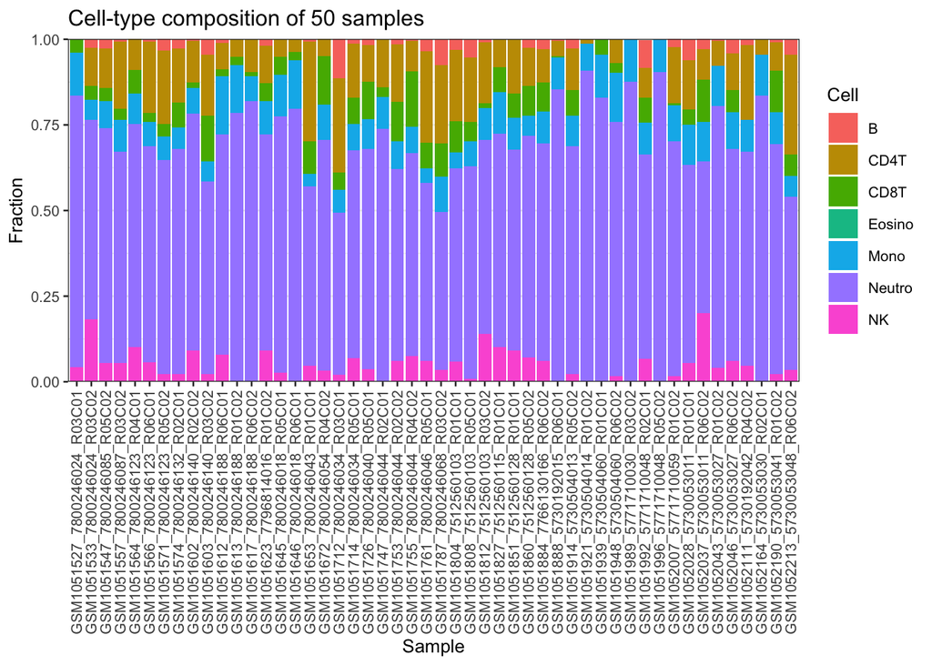

```r
## 1-B: “other” row vs residuals
if (exists("resid") && "other" %in% rownames(frac)) {
  df_tmp <- tibble(other = frac["other", ],
                   residual = resid)
  ggplot(df_tmp, aes(residual, other)) +
    geom_point() + geom_smooth(method = "lm") +
    ggtitle("Samples with high residuals are dominated by 'other'?")
}

# Descriptive plots
## 2-A: stacked bar

frac_long <- frac_t |>
  as.data.frame()              |>
  rownames_to_column("Sample") |>
  pivot_longer(-Sample,
               names_to  = "Cell",
               values_to = "Fraction")

ggplot(frac_long, aes(Sample, Fraction, fill = Cell)) +
  geom_bar(stat = "identity", width = 0.9) +
  scale_y_continuous(expand = c(0, 0)) +
  theme_bw(base_size = 10) +
  theme(axis.text.x = element_text(angle = 90, vjust = 0.5, hjust = 1)) +
  labs(title = "Cell-type composition of 50 samples")
```

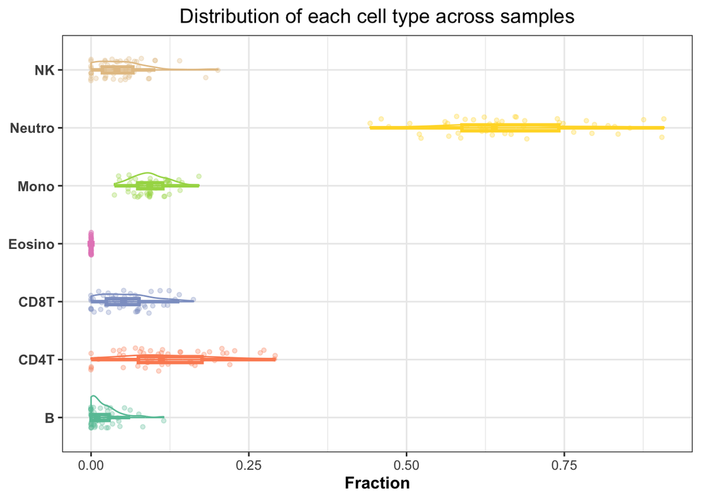

```r
## 2-B: violin per cell type

ggplot(frac_long, aes(x = Cell, y = Fraction, color = Cell)) +
  # violins outlined in colour, no fill
  geom_half_violin(side = "r", trim = TRUE, fill = NA, size = 0.5, alpha = 0.4) +
  # boxplots outlined in same colour, no fill
  geom_boxplot(width = 0.1, fill = NA, size = 1.2, outlier.shape = NA, alpha =1) +
  # optional: overlay points with matching border colour
  geom_jitter(width = 0.2, size = 1.2, alpha = 0.3, shape = 21, aes(fill = Cell)) +
  coord_flip() +
  scale_color_brewer(palette = "Set2") +
  scale_fill_brewer(palette = "Set2") +  # for the point fills
  labs(
    title = "Distribution of each cell type across samples",
    x     = NULL,
    y     = "Fraction"
  ) +
  theme_bw(base_size = 12) +
  theme(
    legend.position = "none",
    axis.text.y     = element_text(size = 10, face = "bold"),
    axis.title.x     = element_text(face = "bold"),
    plot.title      = element_text(hjust = 0.5)
  )
```

```r
#############################################################
## 2. Compositional transform (CLR) & correlation heatmap  ##
#############################################################

# replace zeros (needed before clr) – multiplicative replacement
library(zCompositions)
frac_t_mr   <- zCompositions::cmultRepl(frac_t, label = 0, method = "CZM")
```

```
## No. adjusted imputations:  36
```

```r
clr_mat   <- clr(frac_t_mr)

dim(clr_mat)
```

```
## [1] 50  6
```

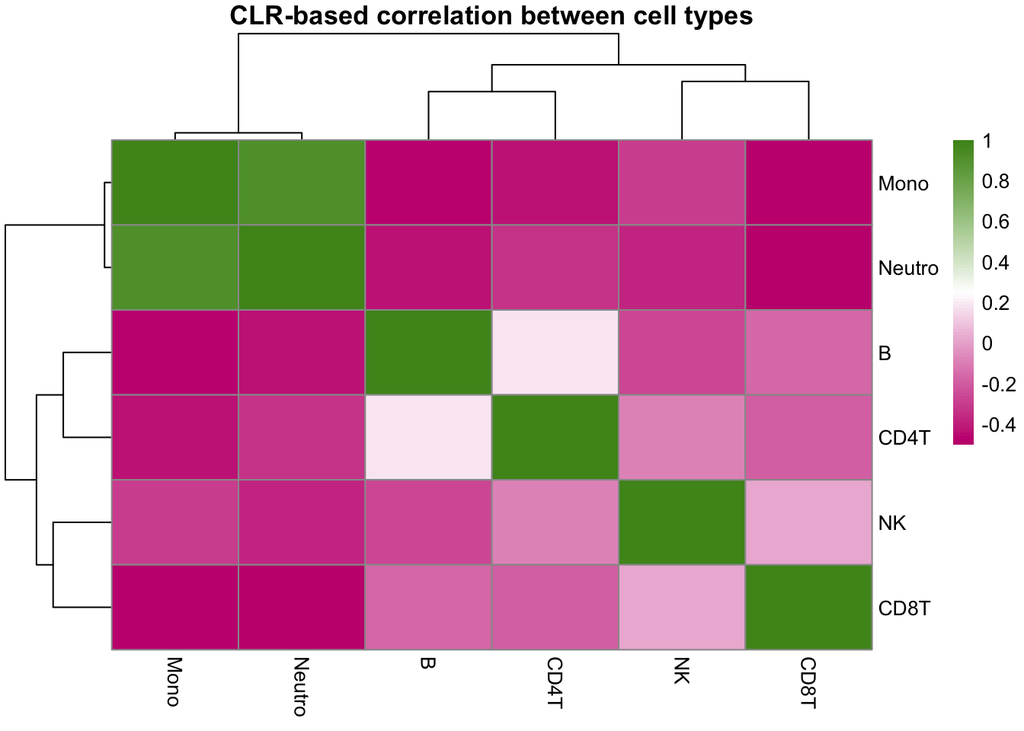

```r
# correlation of clr values
corr <- cor(clr_mat)
pheatmap(corr,
         clustering_distance_rows = "euclidean",
         clustering_distance_cols = "euclidean",
         color = colorRampPalette(c("#c51b7d", "white", "#4d9221"))(100),
         main = "CLR-based correlation between cell types")
```

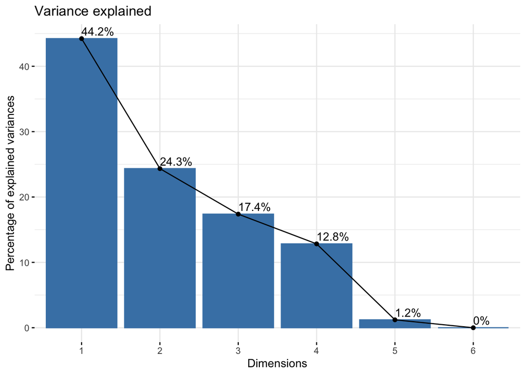

```r
#############################################################
##  3.  PCA + unsupervised clustering                      ##
#############################################################

pca <- PCA(clr_mat, graph = FALSE)
fviz_eig(pca, addlabels = TRUE, barfill = "steelblue") +
  ggtitle("Variance explained")
```

```r
# choose k via silhouette width on first 5 PCs
pc_scores <- pca$ind$coord[, 1:5]
sil_widths <- sapply(2:7, function(k) {
  pam(pc_scores, k)$silinfo$avg.width
})
(k_opt <- which.max(sil_widths) + 1)   # pick the best k
```

```
## [1] 2
```

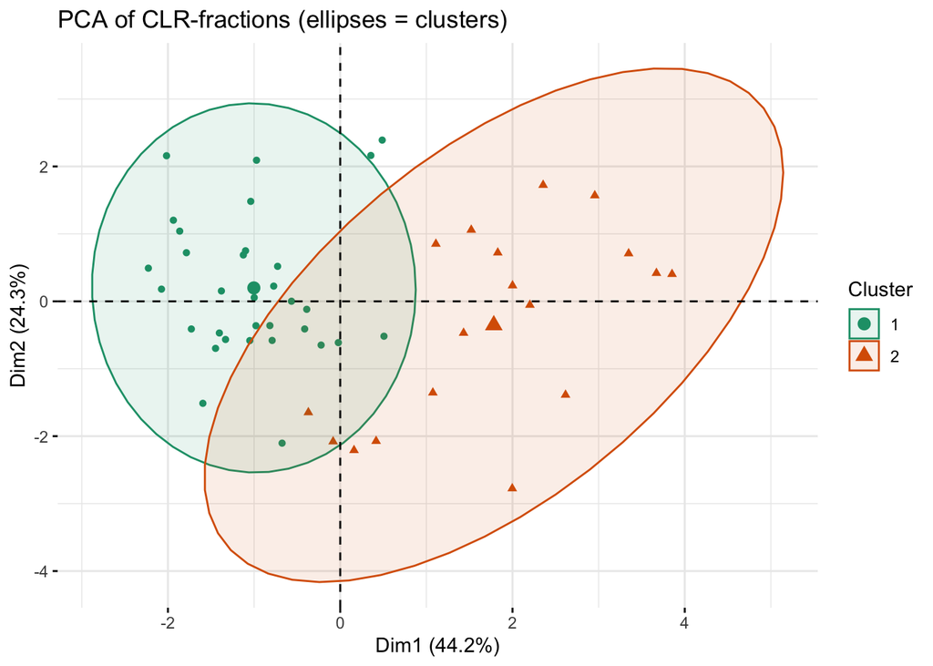

```r
clusters <- pam(pc_scores, k_opt)$clustering

fviz_pca_ind(pca,
             geom.ind  = "point",
             col.ind   = factor(clusters),
             palette   = "Dark2",
             addEllipses = TRUE,
             legend.title = "Cluster") +
  ggtitle("PCA of CLR-fractions (ellipses = clusters)")
```

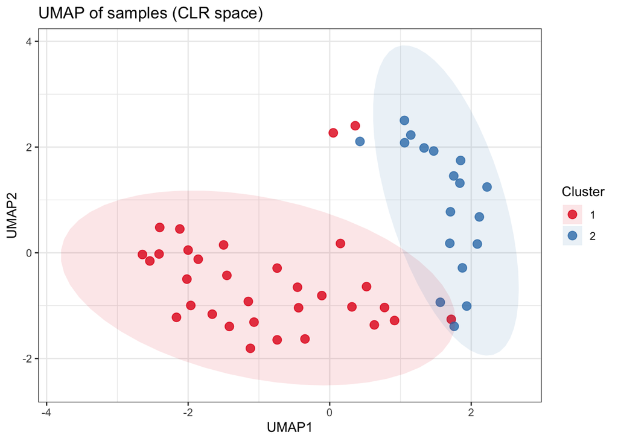

```r
#############################################################
##  5.  UMAP (for non-linear clustering)                   ##
#############################################################

set.seed(123)
Xclr_mat <- as.matrix(clr_mat)
umap_res <- umap(Xclr_mat)

df_umap  <- data.frame(UMAP1 = umap_res$layout[, 1],
                       UMAP2 = umap_res$layout[, 2],
                       Cluster = factor(clusters))

ggplot(df_umap, aes(UMAP1, UMAP2, color = Cluster)) +
  geom_point(size = 3, alpha = 0.8) +
  stat_ellipse(
    aes(fill = Cluster),          # also fill the ellipse
    geom    = "polygon",          # draw as a filled polygon
    alpha   = 0.1,                # transparency
    color   = NA,                 # no border
    level   = 0.95                # 95% confidence ellipse
  ) +
  scale_color_brewer(palette = "Set1") +
  scale_fill_brewer(palette  = "Set1") +
  theme_bw() +
  labs(title = "UMAP of samples (CLR space)")
```

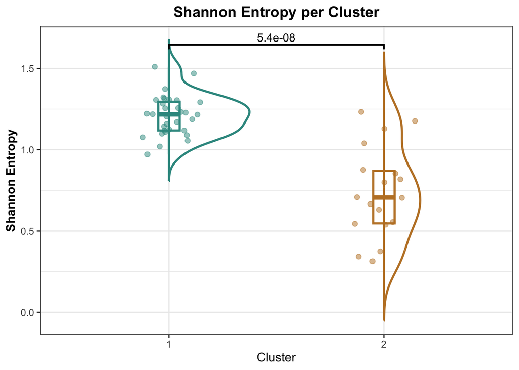

```r
#############################################################
##  5.  Sample-level diversity indices                     ##
#############################################################

shannon <- vegan::diversity(frac_t, index = "shannon")   # vegan

# relate entropy to clusters
# define the pair to compare
my_comparisons <- list(c("1", "2"))

df_entropy <- tibble(
  Shannon = shannon,
  Cluster = factor(clusters)
)

ggplot(df_entropy, aes(x = Cluster, y = Shannon, color = Cluster)) +
  # half‐violin on right
  geom_half_violin(
    side      = "r",
    trim      = FALSE,
    fill      = NA,
    linewidth = 1,
    alpha     = 0.4
  ) +
  # boxplot outline
  geom_boxplot(
    width         = 0.1,
    fill          = NA,
    outlier.shape = NA,
    linewidth     = 1,
    alpha = 1
  ) +
  # jittered points
  geom_jitter(
    width  = 0.15,
    size   = 2,
    alpha  = 0.5
  ) +
  # custom cluster colors
  scale_color_manual(values = c("1" = "#35978f", "2" = "#bf812d")) +
  # draw the bracket and p‐value
  stat_compare_means(
    comparisons  = my_comparisons,    # which groups to compare
    method       = "wilcox.test",
    label        = "p.format",        # formatted p‐value
    tip.length   = 0.02,              # length of the little “tees”
    bracket.size = 0.8,               # thickness of the bar
    label.y      = max(df_entropy$Shannon) * 1.05  # put text just above the tallest point
  ) +
  theme_bw(base_size = 12) +
  labs(
    title = "Shannon Entropy per Cluster",
    x     = "Cluster",
    y     = "Shannon Entropy"
  ) +
  theme(
    legend.position = "none",
    plot.title      = element_text(hjust = 0.5, face = "bold"),
    axis.title.y    = element_text(face = "bold")
  )
```

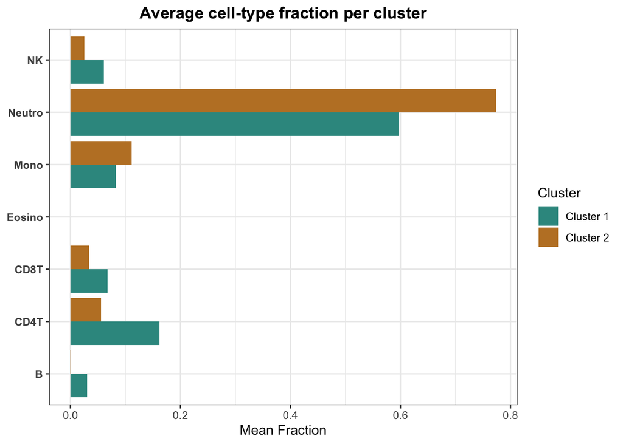

```r
#############################################################
##  6.  Elucidating the clusters                             ##
#############################################################

X <- frac_t

# after PAM or k-means:
clusters <- pam(pc_scores, k_opt)$clustering

mean_by_cl <- X %>%
  as.data.frame() %>%
  mutate(Cluster = clusters ) %>%
  group_by(Cluster) %>%
  summarise(across(everything(), mean)) %>%
  pivot_longer(-Cluster, names_to = "Cell", values_to = "MeanFrac")

my_cols <- c(
  "1" = "#35978f",   # cluster 1
  "2" = "#bf812d"    # cluster 2
)

mean_by_cl_c <- mean_by_cl %>%
  mutate(Cluster = factor(Cluster, levels = c(1,2),
                          labels = c("Cluster 1","Cluster 2")))

ggplot(mean_by_cl_c, aes(Cell, MeanFrac, fill = Cluster)) +
  geom_col(position = "dodge") +
  scale_fill_manual(
    values = c("Cluster 1" = "#35978f", "Cluster 2" = "#bf812d")
  ) +
  coord_flip() +
  theme_bw() +
  labs(
    title = "Average cell-type fraction per cluster",
    x     = NULL,
    y     = "Mean Fraction"
  ) +
  theme(
    plot.title      = element_text(hjust = 0.5, face = "bold"),
     axis.text.y     = element_text(face = "bold"),  # ← bold tick labels
    axis.title.y    = element_text(face = "bold"),   # ← bold axis title
    legend.position = "right"
  )
```

```r
#############################################################
##  7.  Decision Tree for cluster elucidation              ##
#############################################################
df <- cbind(X, Cluster = clusters)
df
```

```
##                                  B    NK  CD4T  CD8T  Mono Neutro Eosino
## GSM1052046_5730053027_R06C02 0.042 0.061 0.107 0.064 0.107  0.619      0
## GSM1051753_7800246044_R02C02 0.015 0.061 0.169 0.115 0.080  0.561      0
## GSM1052111_5730192042_R04C02 0.016 0.046 0.220 0.000 0.093  0.625      0
## GSM1052007_5771710059_R01C02 0.023 0.016 0.165 0.005 0.105  0.687      0
## GSM1051948_5730504060_R06C02 0.000 0.017 0.070 0.027 0.144  0.742      0
## GSM1052043_5730053027_R01C02 0.004 0.040 0.074 0.000 0.117  0.765      0
## GSM1051566_7800246123_R06C01 0.007 0.056 0.207 0.028 0.070  0.632      0
## GSM1051939_5730504060_R01C01 0.000 0.000 0.000 0.046 0.124  0.830      0
## GSM1051533_7800246024_R03C02 0.024 0.182 0.113 0.039 0.060  0.582      0
## GSM1051613_7800246188_R01C02 0.000 0.000 0.052 0.024 0.139  0.785      0
## GSM1051547_7800246085_R05C02 0.026 0.055 0.117 0.038 0.079  0.685      0
## GSM1052164_5730053030_R02C01 0.000 0.000 0.045 0.000 0.120  0.835      0
## GSM1051860_7512560128_R05C02 0.025 0.072 0.112 0.086 0.059  0.646      0
## GSM1051726_7800246040_R05C01 0.018 0.036 0.107 0.109 0.088  0.643      0
## GSM1051827_7512560115_R01C01 0.000 0.102 0.080 0.073 0.121  0.623      0
## GSM1051653_7800246043_R01C01 0.006 0.047 0.292 0.095 0.037  0.523      0
## GSM1051787_7800246068_R03C02 0.076 0.035 0.228 0.098 0.103  0.460      0
## GSM1051564_7800246123_R04C01 0.000 0.101 0.090 0.070 0.089  0.651      0
## GSM1051557_7800246087_R03C02 0.007 0.054 0.196 0.033 0.093  0.617      0
## GSM1051914_5730504013_R05C02 0.027 0.022 0.122 0.076 0.088  0.666      0
## GSM1051623_7796814016_R01C02 0.018 0.092 0.111 0.052 0.096  0.631      0
## GSM1051714_7800246034_R05C01 0.012 0.069 0.159 0.076 0.078  0.606      0
## GSM1051645_7800246018_R05C01 0.000 0.026 0.051 0.053 0.122  0.748      0
## GSM1051603_7800246140_R03C02 0.044 0.023 0.179 0.133 0.059  0.561      0
## GSM1051617_7800246188_R06C02 0.000 0.000 0.094 0.012 0.074  0.819      0
## GSM1051884_7766130166_R06C02 0.029 0.060 0.097 0.084 0.094  0.636      0
## GSM1051612_7800246188_R06C01 0.010 0.080 0.078 0.019 0.171  0.642      0
## GSM1051712_7800246034_R03C01 0.115 0.021 0.274 0.051 0.068  0.472      0
## GSM1051996_5771710048_R05C02 0.000 0.000 0.000 0.000 0.095  0.905      0
## GSM1052028_5730053011_R01C01 0.062 0.054 0.142 0.045 0.118  0.579      0
## GSM1051571_7800246123_R05C02 0.034 0.022 0.215 0.035 0.069  0.626      0
## GSM1051672_7800246054_R04C02 0.000 0.033 0.051 0.140 0.103  0.674      0
## GSM1051888_5730192015_R06C01 0.005 0.000 0.045 0.003 0.093  0.854      0
## GSM1051921_5730504014_R01C02 0.000 0.000 0.012 0.000 0.080  0.908      0
## GSM1051812_7512560103_R03C02 0.007 0.140 0.178 0.015 0.092  0.567      0
## GSM1051646_7800246018_R06C01 0.000 0.000 0.035 0.025 0.141  0.798      0
## GSM1051808_7512560103_R05C01 0.053 0.008 0.188 0.056 0.074  0.621      0
## GSM1052190_5730053041_R01C02 0.009 0.022 0.083 0.121 0.093  0.672      0
## GSM1051574_7800246132_R02C01 0.027 0.023 0.157 0.074 0.063  0.656      0
```

[output cut: 47 more lines]

```
## GSM1051646_7800246018_R06C01       2
## GSM1051808_7512560103_R05C01       1
## GSM1052190_5730053041_R01C02       1
## GSM1051574_7800246132_R02C01       1
## GSM1051992_5771710048_R02C01       1
## GSM1051804_7512560103_R01C01       1
## GSM1052213_5730053048_R06C02       1
## GSM1051527_7800246024_R03C01       2
## GSM1051602_7800246140_R02C02       1
## GSM1051747_7800246044_R02C01       2
## GSM1051755_7800246044_R04C02       1
## GSM1051851_7512560128_R01C01       2
## GSM1052037_5730053011_R06C02       1
## GSM1051989_5771710030_R03C02       2
## GSM1051761_7800246046_R05C01       1
```

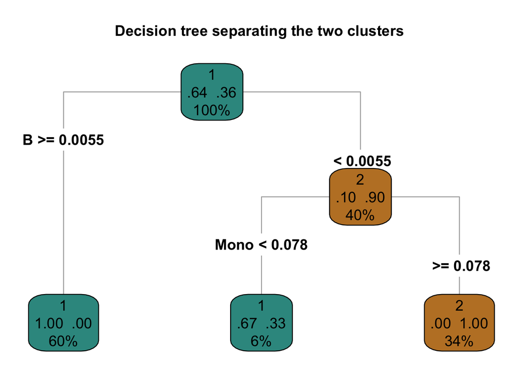

```r
# X = samples × cell-types  (still a matrix)
# cluster_id = vector of length nSamples with the PAM/k-means labels

tree_df <- X |>
  as.data.frame() |>                 # <- matrix ➜ data-frame
  mutate(Cluster = factor(clusters))    # add the label column

# now run rpart on the data-frame
library(rpart)
tree <- rpart(
  Cluster ~ .,
  data    = tree_df,
  method  = "class",
  parms   = list(split = "information"),
  control = rpart.control(cp = 0.01, minsplit = 5)
)


# Define a two-colour palette (one per cluster)
my_palette <- c("#35978f", "#bf812d")

rpart.plot(
  tree,
  type          = 4,      # label all nodes
  extra         = 104,    # show class and prob info
  fallen.leaves = TRUE,

  # --- NEW COLOUR OPTIONS ---
  box.palette   = my_palette,   # fill colours for the node boxes
  branch.col    = "darkgrey",   # branch line colour
  shadow.col    = NA,           # remove box shadow
  nn            = FALSE,         # display node numbers
  tweak         = 1.2,          # scale up text slightly

  main = "Decision tree separating the two clusters"
)
```

# Differential analysis

## Gene annotation

```r
annot<-readr::read_tsv("https://github.com/zhou-lab/InfiniumAnnotationV1/raw/main/Anno/HM450/HM450.hg38.manifest.gencode.v37.tsv.gz") %>%
  dplyr::rename(Probe_ID=probeID)
annot2<-readr::read_tsv("https://github.com/zhou-lab/InfiniumAnnotationV1/raw/main/Anno/EPIC/EPIC.hg38.manifest.gencode.v37.tsv.gz") %>%
  dplyr::rename(Probe_ID=probeID)
# checking the overlapping CpGs
intersect <- intersect(bulk_sample$CpGs, annot$Probe_ID)
length(intersect)
```

```
## [1] 444
```

## Density plot - QC

The β-value density plots across samples showed no obvious outliers, although a few curves deviated from the expected bimodal distribution. The M-value density plots exhibited unusually peaks in some samples, which could reflect batch effects, different tissue origins, or variability in experimental quality or preprocessing.

```r
names(bulk_sample)[names(bulk_sample) == "CpGs"] <- "Probe_ID"
meth <- bulk_sample
rownames(meth) <- meth$Probe_ID
meth <- meth[ , -1]
dim(meth)
```

```
## [1] 500  50
```

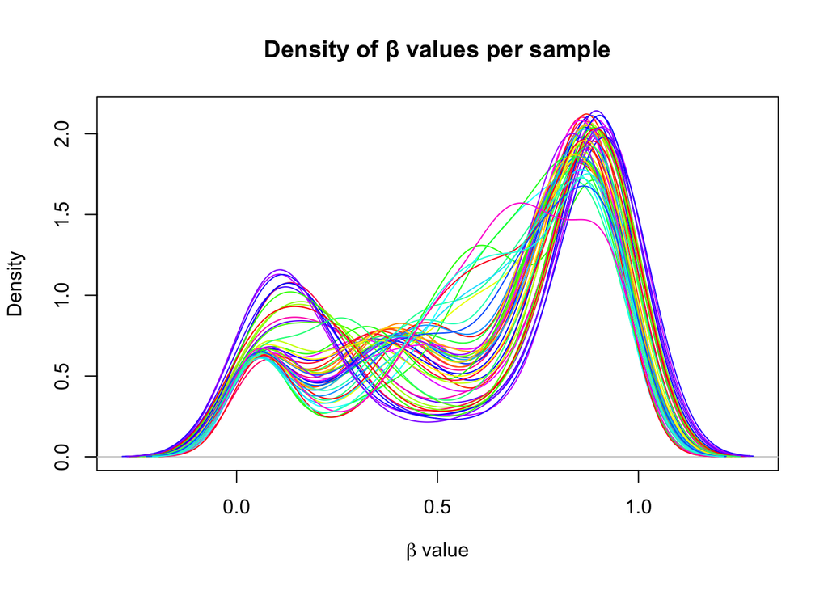

```r
meth <- as.matrix(meth)

n <- ncol(meth)

densityPlot(
  meth,
  sampGroups = colnames(meth),        # one group label per sample
  sampNames  = colnames(meth),        # put sample names in the legend
  pal        = rainbow(n),            # <- now a colour *vector*
  legend     = FALSE,                 # draw your own if you wish
  xlab       = expression(beta~value),
  main       = "Density of β values per sample"
)
```

## Filter NA CpG

To improve the power of downstream analyses, CpG probes with missing data in ≥ 20% of samples were filtered out.

```r
# 1. choose the NA-threshold
na_cutoff <- 0.20

# 2. calculate the fraction of NA in each probe (row)
na_frac <- rowMeans(is.na(meth))

# 3. keep rows where that fraction ≤ threshold
beta_filt <- meth[ na_frac <= na_cutoff , ]

# 4. (optional) report how many probes you kept / removed
cat(
  sprintf("Kept %s of %s probes (%.1f %%); removed %s (%.1f %%)\n",
          nrow(beta_filt), length(na_frac),
          100 * nrow(beta_filt) / length(na_frac),
          sum(na_frac > na_cutoff),
          100 * sum(na_frac > na_cutoff) / length(na_frac))
)
```

```
## Kept 500 of 500 probes (100.0 %); removed 0 (0.0 %)
```

## Convert to M-value

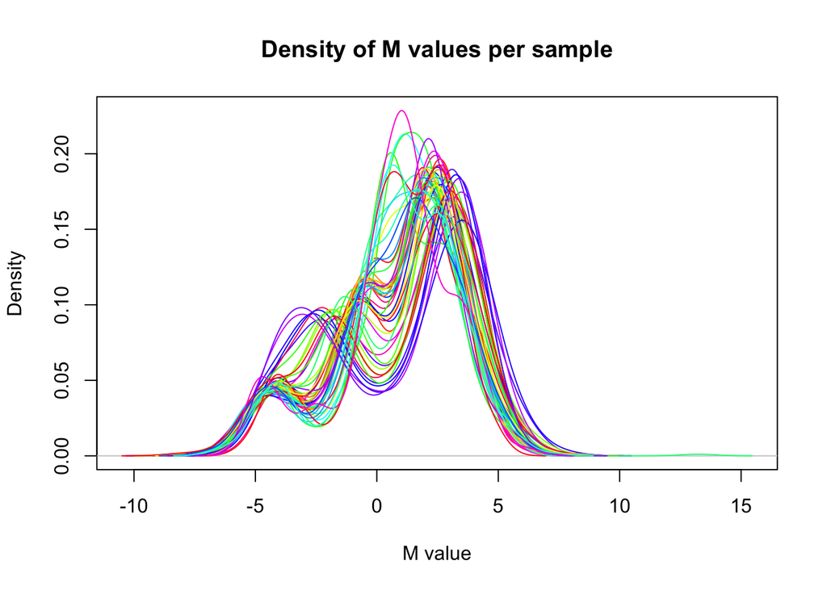

```r
methM <- beta2m(meth)
n <- ncol(methM)

densityPlot(
  methM,
  sampGroups = colnames(methM),
  sampNames  = colnames(methM),
  pal        = rainbow(n),
  legend     = FALSE,
  xlab       = "M value",
  main       = "Density of M values per sample"
)
```

## Create SummarizedExperiment object

```r
# probes:

key <- "Probe_ID"
anno_df <- annot[, c(key, setdiff(names(annot), key))]

## --- 3.  produce a complete row-annotation table (same order as methM) ------
all_probes <- rownames(methM)

row_df <- anno_df[ match(all_probes, annot[[key]]), ]   # keeps order of methM

row_df <- as.data.frame(row_df)

rownames(row_df) <- all_probes

table(complete.cases(row_df))
```

```
##
## FALSE  TRUE
##    56   444
```

```r
# samples:
stopifnot(all(colnames(methM) %in% rownames(df)))
col_df <- df[ match(colnames(methM), rownames(df)), ]

se <- SummarizedExperiment(
  assays  = list(Mvalue = methM),
  colData = DataFrame(col_df),      # your sample metadata (clusters, etc.)
  rowData = DataFrame(row_df)       # annotation + NA rows
)

se
```

```
## class: SummarizedExperiment
## dim: 500 50
## metadata(0):
## assays(1): Mvalue
## rownames(500): cg26930596 cg08884752 ... cg08314679 cg09113560
## rowData names(10): Probe_ID CpG_chrm ... transcriptIDs distToTSS
## colnames(50): GSM1052046_5730053027_R06C02 GSM1051753_7800246044_R02C02
##   ... GSM1051989_5771710030_R03C02 GSM1051761_7800246046_R05C01
## colData names(8): B NK ... Eosino Cluster
```

## DMP findings

To investigate the differences of DNA methylation profiles between 2 clusters, linear regression model with limma was fitted with empirical Bayes method to moderate the standard errors of the estimated log-fold changes.

The top differentially methylated CpG sites (FDR-adjusted) were then visualized with volcano plots.

```r
#############################################################
##  0.  Setup                                              ##
#############################################################

m_mat   <- assay(se, "Mvalue")
clusters <- factor(se$Cluster)
table(clusters)
```

```
## clusters
##  1  2
## 32 18
```

```r
#############################################################
##  1.  Design & contrasts                                 ##
#############################################################

design <- model.matrix(~ 0 + clusters)     # no intercept: one column per group
colnames(design) <- levels(clusters)       # e.g. "1"  "2"

colnames(design) <- c("Cluster1", "Cluster2")
contrast.mat <- makeContrasts(
  diff = Cluster2 - Cluster1,    # Cluster 2 minus Cluster 1
  levels = design
)

#############################################################
##  2.  Fit the linear model                               ##
#############################################################

fit  <- lmFit(m_mat, design)
fit2 <- contrasts.fit(fit, contrast.mat)
fit2 <- eBayes(fit2)

#############################################################
##  3.  Extract results                                    ##
#############################################################

top <- topTable(
  fit2,
  coef      = "diff",          # the contrast we named above
  number    = Inf,             # all probes
  sort.by   = "P",
  adjust    = "BH"             # FDR
)

# quick overview
head(top[, c("logFC", "AveExpr", "t", "P.Value", "adj.P.Val")])
```

```
##                logFC    AveExpr         t      P.Value    adj.P.Val
## cg25605731 -1.171941 -1.0212304 -9.392382 6.007415e-13 3.003708e-10
## cg21341487 -1.099075 -1.2880548 -9.126169 1.573542e-12 3.933855e-10
## cg14059339 -1.372633 -0.9458381 -8.858620 4.169332e-12 5.364141e-10
## cg14985891 -1.370708 -1.1506689 -8.850728 4.291313e-12 5.364141e-10
## cg23363263 -1.342355 -0.4374194 -8.744296 6.334651e-12 5.739236e-10
## cg19082496 -1.192959 -0.7805113 -8.624455 9.832121e-12 5.739236e-10
```

```r
# how many genome-wide significant?
sum(top$adj.P.Val < 0.05)
```

```
## [1] 302
```

```r
# add annotation columns if you stored them in rowData(se)
top_anno <- cbind(
  rowData(se)[rownames(top), ],  # annotation
  top                                # statistics
)

dim(top_anno)
```

```
## [1] 500  16
```

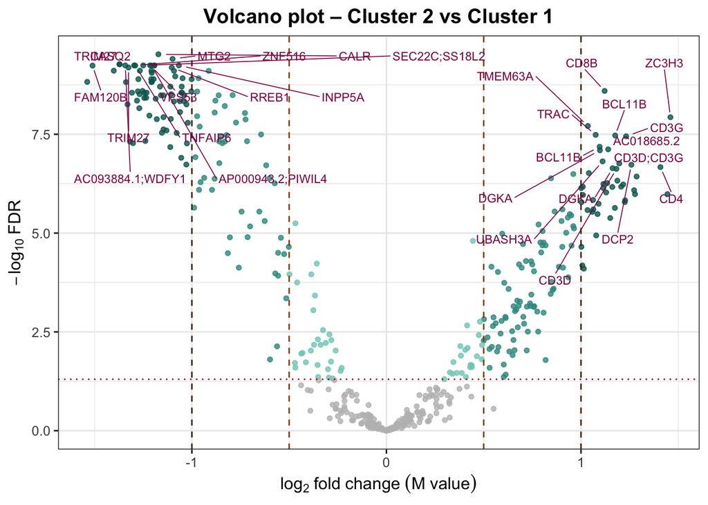

```r
#############################################################
##  4.  Save & plot                                         ##
#############################################################

write.csv(top_anno, "DMPs_Cluster2_vs_Cluster1.csv", row.names = FALSE)

# Volcano
top_anno <- as.data.frame(top_anno)
## 1 ──────────────────────────────────────────────────────────
##  Classify each CpG for colour & label
## ────────────────────────────────────────────────────────────
volc <- top_anno %>%
  mutate(
    negLog10FDR = -log10(adj.P.Val),
    absLFC      = abs(logFC),
    class = case_when(
      adj.P.Val < 0.05 & absLFC >= 1        ~ "FDR<0.05 & |LFC|≥1",
      adj.P.Val < 0.05 & absLFC >= 0.5      ~ "FDR<0.05 & 0.5≤|LFC|<1",
      adj.P.Val < 0.05 & absLFC < 0.5       ~ "FDR>0.05",
      TRUE ~ "NS"
    )
  )

##  colour palette
my_cols <- c(
  "FDR<0.05 & |LFC|≥1"   = "#01665e",   # red
  "FDR<0.05 & 0.5≤|LFC|<1" = "#35978f", # blue
  "FDR>0.05"             = "#80cdc1",
  "NS" = "grey"
)

label_df <- volc %>%
  filter(adj.P.Val < 0.05) %>%                # only significant ones
  group_by(direction = sign(logFC)) %>%       # -1 = hypo, 1 = hyper
  slice_min(order_by = adj.P.Val, n = 15) %>%  # 5 per direction
  ungroup()

## 2 ──────────────────────────────────────────────────────────
##  Volcano plot
## ────────────────────────────────────────────────────────────
library(ggplot2)
library(ggrepel)
library(dplyr)
ggplot(volc, aes(x = logFC, y = negLog10FDR, colour = class)) +
  geom_point(size = 1.3, alpha = 0.8) +
  scale_colour_manual(values = my_cols, name = NULL) +

  ## threshold lines
  geom_vline(xintercept = c(-1, 1),  linetype = "dashed", colour = "#543005") +
  geom_vline(xintercept = c(-0.5, 0.5), linetype = "dashed", colour = "#8c510a") +
  geom_hline(yintercept = -log10(0.05), linetype = "dotted", colour = "#b2182b") +
  geom_text_repel(
    data        = label_df,
    aes(label = genesUniq),
    colour      = "#8e0152",
    max.overlaps = Inf,
    size         = 3,
    segment.size = 0.3,
    box.padding  = 0.8,
    point.padding= 0.6,
    force = 1.5,
    seed         = 123
  ) +

  ## aesthetics
  labs(
    title    = "Volcano plot – Cluster 2 vs Cluster 1",
    x        = expression(log[2]~fold~change~(M~value)),
    y        = expression(-log[10]~FDR)
  ) +
  theme_bw(base_size = 12) +
  theme(
    plot.title      = element_text(hjust = .5, face = "bold"),
    legend.position = "none"
  )
```

## DMR findings

```r
# DMR finding with DMRcate
## DMR analysis manually

contrast.mat <- limma::makeContrasts(Cluster2 - Cluster1, levels = design)
myannotation <- cpg.annotate(
  datatype      = "array",
  what = "M",
  object        = methM,               # M-value matrix (CpGs × samples)
  design        = design,          # model matrix with your Cluster column
  analysis.type = "differential",
  contrasts     = TRUE,
  cont.matrix   = contrast.mat,
  coef = "Cluster2 - Cluster1",
  arraytype     = "450K"           # or "450K"
)
```

```
## Your contrast returned 302 individually significant probes. We recommend the default setting of pcutoff in dmrcate().
```

```r
dmrcoutput<- DMRcate::dmrcate(myannotation,C=2, pcutoff=0.05, lambda = 1000)
```

[output not shown]

[output not shown]

[output not shown]

[output not shown]

[output not shown]

[output not shown]

[output not shown]

[output not shown]

[output not shown]

[output not shown]

[output not shown]

[output not shown]

[output not shown]

[output not shown]

[output not shown]

[output not shown]

[output not shown]

[output not shown]

[output not shown]

[output not shown]

[output not shown]

[output not shown]

```
## Demarcating regions...
```

```
## Done!
```

```r
dmr_table <- DMRcate::extractRanges(dmrcoutput, genome = "hg38")
```

```
## see ?DMRcatedata and browseVignettes('DMRcatedata') for documentation
```

```
## loading from cache
```

## Circosplot

A circos plot was used to visualize the chromosomal distribution of differentially methylated positions (DMPs).

```r
results <- top_anno %>%
  mutate(deltaBeta = 2^(logFC/2) / (1 + 2^(logFC/2)) -
                     2^(-logFC/2) / (1 + 2^(-logFC/2)))

## 2.  merge so we have chr, pos, deltaBeta
res_annot <- results %>%
        filter(!is.na(Probe_ID))               # keep only mapped probes
res_annot <- res_annot[res_annot$adj.P.Val < 0.05, ]
dim(res_annot)
```

```
## [1] 270  17
```

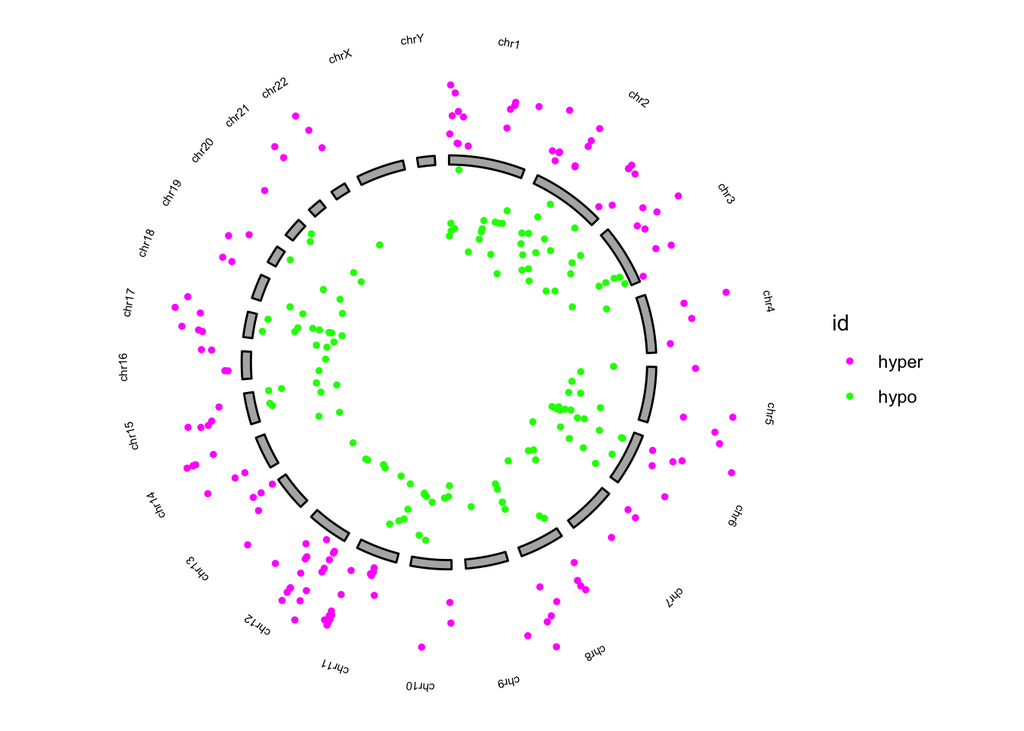

```r
## 3.  build GRanges with the required metadata slots ------------------------
ranges <- GRanges(
  seqnames = res_annot$CpG_chrm,
  ranges   = IRanges(start = res_annot$CpG_beg,
                     end   = res_annot$CpG_end),       # CpGs: single-bp
  deltabetas = res_annot$deltaBeta,
  midpoint   = res_annot$CpG_beg                       # single-point so start==midpoint
)

## 4.  draw the circos plot ---------------------------------------------------
p <- circosplot(ranges, genome = "hg38")
print(p)
```